# Pooled-wallet Efron top-30 majors backtest

This notebook reconstructs the current best **defensible baseline** from validated artifacts: prior-three-month pooled-wallet capped daily-PnL t-stat, t-to-z empirical-Bayes `p_informed`, monthly top 30, BTC/ETH/SOL/HYPE, fixed $5k entries, one concurrent position per wallet×coin, $50k per-coin cap, 8-hour exit, and 5.5 bp cost.

It does **not** rerun the expensive selector or data ingest. It rebuilds the globally chronological capacity book from frozen entries and asserts exact agreement with the audited report before computing EDA. Consensus/opinion trading and the >500-fills/day screen are excluded. The eight folds are burned; all performance statistics here are descriptive, not fresh OOS evidence.

```python
from pathlib import Path
import json
import math
import sys

import matplotlib.pyplot as plt
import numpy as np
import pandas as pd

ROOT = next(p for p in (Path.cwd(), *Path.cwd().parents) if (p / 'research/studies/copy_cohort').exists())
if str(ROOT) not in sys.path:
    sys.path.insert(0, str(ROOT))

from research.studies.copy_cohort import wallet_coin_t30 as wc

plt.style.use('seaborn-v0_8-whitegrid')
pd.set_option('display.max_columns', 30)
pd.set_option('display.float_format', lambda x: f'{x:,.3f}')
ROOT
```

```
PosixPath('/Users/corywagamaneure/bablyon')
```

## 1. Reconstruct and verify the audited book

The notebook deliberately reuses the audited entry loader and capacity simulator. Reimplementing those rules independently inside a charting notebook would create a second, unaudited backtest engine.

```python
report = json.loads(wc.OUT.read_text())
roster_report = json.loads(wc.ROSTERS.read_text())
assert report['status'] == 'BURNED_REOPENED_WALLET_COIN_FORENSIC_BOOK'
assert report['config']['consensus'] == 'excluded'
assert report['positive_promotion_eligible'] is False
assert report['method_null_eligible'] is False
assert wc.file_sha256(wc.ROSTERS) == report['config']['roster_report_sha256']
assert wc._code_sha256(Path(wc.__file__)) == report['config']['code_sha256']
assert wc.dependency_hashes() == report['config']['dependency_hashes']
for fold in wc.FOLDS:
    path = wc.ENTRIES / f'entries_{fold}.parquet'
    record = report['config']['entry_records'][str(fold)]
    assert wc.entry_data_record(path) == record['parquet']
    assert wc.file_sha256(path.with_suffix('.meta.json')) == record['meta_sha256']

parts = [wc.load_entries(wc.ENTRIES / f'entries_{fold}.parquet', fold) for fold in wc.FOLDS]
entries = wc._concat(parts)
rosters = {str(fold): roster_report['folds'][str(fold)]['rosters']['WALLET_E30'] for fold in wc.FOLDS}
capacity, funnels = wc.capacity_book(entries, rosters, 'WALLET_E30')
book = wc.supported(capacity)
expected = report['books']['WALLET_E30']

assert len(book['net_bp']) == expected['n_entries']
assert np.isclose(book['net_bp'].mean(), expected['net_mean_bp_per_trade'], atol=1e-12)
assert np.isclose(np.median(book['net_bp']), expected['net_median_bp_per_trade'], atol=1e-12)
assert np.isclose(book['net_bp'].sum() * wc.UNIT_USD / 1e4, expected['net_usd'], atol=1e-8)
assert wc._rows_sha(book, 'net_bp') == expected['supported_multiset_sha256']
assert wc._ordered_rows_sha(book, 'net_bp') == expected['supported_ordered_sha256']
assert funnels == report['funnels']['WALLET_E30']
assert int((~capacity['supported']).sum()) == expected['missingness']['missing']

verification = pd.Series({
    'selector': 'pooled-wallet Efron top-30',
    'accepted capacity entries': len(capacity['net_bp']),
    'supported entries': len(book['net_bp']),
    'missing outcomes': int((~capacity['supported']).sum()),
    'net mean bp/trade': book['net_bp'].mean(),
    'net median bp/trade': np.median(book['net_bp']),
    'net PnL $': book['net_bp'].sum() * wc.UNIT_USD / 1e4,
    'hash-bound audited artifact reproduced': True,
})
verification.to_frame('value')
```

|  | value |
| --- | --- |
| selector | pooled-wallet Efron top-30 |
| accepted capacity entries | 1760 |
| supported entries | 1745 |
| missing outcomes | 15 |
| net mean bp/trade | 16.238 |
| net median bp/trade | -0.275 |
| net PnL $ | 14,167.714 |
| hash-bound audited artifact reproduced | True |

```python
trades = pd.DataFrame({
    'wallet': book['wallet'],
    'coin': book['coin'],
    'fold': book['fold'].astype(str),
    'direction': np.where(book['dir_sign'] > 0, 'long', 'short'),
    'entry_time': pd.to_datetime(book['ts'], unit='ms', utc=True),
    'gross_bp': book['gross_bp'],
    'net_bp': book['net_bp'],
})
trades['exit_time'] = trades['entry_time'] + pd.Timedelta(hours=8)
trades['gross_usd'] = trades['gross_bp'] * wc.UNIT_USD / 1e4
trades['net_usd'] = trades['net_bp'] * wc.UNIT_USD / 1e4
trades['exit_day'] = trades['exit_time'].dt.floor('D')
trades = trades.sort_values(['exit_time', 'wallet', 'coin']).reset_index(drop=True)
trades.head()
```

|  | wallet | coin | fold | direction | entry_time | gross_bp | net_bp | exit_time | gross_usd | net_usd | exit_day |
| --- | --- | --- | --- | --- | --- | --- | --- | --- | --- | --- | --- |
| 0 | 0xa1b6d8efbcb2fb750a84dbc05649fa4968034f04 | HYPE | 202511 | long | 2025-11-01 01:03:08.022000+00:00 | -114.721 | -120.221 | 2025-11-01 09:03:08.022000+00:00 | -57.360 | -60.110 | 2025-11-01 00:00:00+00:00 |
| 1 | 0x6c30f71877c53ab67f296b5fcd07924131c02d59 | HYPE | 202511 | long | 2025-11-01 01:03:14.828000+00:00 | -114.721 | -120.221 | 2025-11-01 09:03:14.828000+00:00 | -57.360 | -60.110 | 2025-11-01 00:00:00+00:00 |
| 2 | 0x329c787b163a730bd7900df2beb3ff4fe4670375 | HYPE | 202511 | short | 2025-11-01 02:30:54.529000+00:00 | 35.245 | 29.745 | 2025-11-01 10:30:54.529000+00:00 | 17.622 | 14.872 | 2025-11-01 00:00:00+00:00 |
| 3 | 0x6f4823e660915982cc7a58ba9287e9d4bb39ae12 | HYPE | 202511 | short | 2025-11-01 02:47:09.875000+00:00 | 90.400 | 84.900 | 2025-11-01 10:47:09.875000+00:00 | 45.200 | 42.450 | 2025-11-01 00:00:00+00:00 |
| 4 | 0xa1b6d8efbcb2fb750a84dbc05649fa4968034f04 | HYPE | 202511 | long | 2025-11-01 17:34:44.908000+00:00 | -366.146 | -371.646 | 2025-11-02 01:34:44.908000+00:00 | -183.073 | -185.823 | 2025-11-02 00:00:00+00:00 |

## 2. Daily equity conventions and headline statistics

Closed-trade PnL is credited on the 8-hour **exit UTC day**. The daily frame contains every calendar day from 2025-11-01 through 2026-06-30, including zero-PnL days. Sharpe and Sortino use $\sqrt{365}$ annualization and are descriptive within this frozen horizon. Sortino's denominator is the root mean square of `min(daily PnL, 0)` over the full calendar. Drawdown begins from zero equity.

```python
calendar = pd.date_range('2025-11-01', '2026-06-30', freq='D', tz='UTC')
daily = trades.groupby('exit_day')[['gross_usd', 'net_usd']].sum().reindex(calendar, fill_value=0.0)
daily.index.name = 'day'
daily['equity'] = daily['net_usd'].cumsum()
running_peak = np.maximum.accumulate(np.r_[0.0, daily['equity'].to_numpy()])[1:]
daily['drawdown'] = daily['equity'] - running_peak
daily['rolling_30d_pnl'] = daily['net_usd'].rolling(30, min_periods=1).sum()
daily['rolling_30d_sharpe'] = (
    daily['net_usd'].rolling(30, min_periods=15).mean()
    / daily['net_usd'].rolling(30, min_periods=15).std(ddof=1) * np.sqrt(365)
)

def exposure_stats(cap):
    events = [(int(t), 1) for t in cap['ts']] + [(int(t) + wc.HOLD_MS, -1) for t in cap['ts']]
    events.sort(key=lambda x: (x[0], x[1]))  # exits before simultaneous entries
    start = int(pd.Timestamp('2025-11-01', tz='UTC').timestamp() * 1000)
    end = int(pd.Timestamp('2026-07-01', tz='UTC').timestamp() * 1000)
    current = maximum = area = 0
    last = start
    for ts, delta in events:
        ts = min(max(ts, start), end)
        area += current * (ts - last)
        current += delta
        maximum = max(maximum, current)
        last = ts
    area += current * (end - last)
    return area / (end - start) * wc.UNIT_USD, maximum * wc.UNIT_USD

avg_exposure, max_exposure = exposure_stats(capacity)
mu = daily['net_usd'].mean()
sd = daily['net_usd'].std(ddof=1)
downside = np.sqrt(np.mean(np.minimum(daily['net_usd'], 0.0) ** 2))
positive_trade_pnl = trades.loc[trades['net_usd'] > 0, 'net_usd'].sum()
negative_trade_pnl = -trades.loc[trades['net_usd'] < 0, 'net_usd'].sum()
active_days = daily['net_usd'] != 0
exit_month_pnl = daily['net_usd'].resample('ME').sum()
missing_n = int((~capacity['supported']).sum())
adverse_pnl = trades['net_usd'].sum() - missing_n * wc.MISSING_BOUND_BP * wc.UNIT_USD / 1e4
favorable_pnl = trades['net_usd'].sum() + missing_n * wc.MISSING_BOUND_BP * wc.UNIT_USD / 1e4
adverse_mean_bp = (trades['net_bp'].sum() - missing_n * wc.MISSING_BOUND_BP) / len(capacity['net_bp'])
favorable_mean_bp = (trades['net_bp'].sum() + missing_n * wc.MISSING_BOUND_BP) / len(capacity['net_bp'])

stats = pd.Series({
    'supported trades': len(trades),
    'accepted / missing outcomes': f"{len(capacity['net_bp'])} / {(~capacity['supported']).sum()}",
    'net PnL $': trades['net_usd'].sum(),
    'net mean bp/trade': trades['net_bp'].mean(),
    'net median bp/trade': trades['net_bp'].median(),
    'trade hit rate': (trades['net_bp'] > 0).mean(),
    'profit factor': positive_trade_pnl / negative_trade_pnl,
    'annualized daily Sharpe': mu / sd * np.sqrt(365),
    'annualized daily Sortino': mu / downside * np.sqrt(365),
    'maximum drawdown $': -daily['drawdown'].min(),
    'max DD / max gross exposure': -daily['drawdown'].min() / max_exposure,
    'active days / calendar days': f'{active_days.sum()} / {len(daily)}',
    'positive active-day rate': (daily.loc[active_days, 'net_usd'] > 0).mean(),
    'positive exit-calendar months': int((exit_month_pnl > 0).sum()),
    'missing-stress net mean bp range': f'{adverse_mean_bp:.3f} to {favorable_mean_bp:.3f}',
    'missing-stress net PnL $ range': f'${adverse_pnl:,.2f} to ${favorable_pnl:,.2f}',
    'average gross exposure $': avg_exposure,
    'maximum gross exposure $': max_exposure,
    'lag-1 daily PnL autocorrelation': daily['net_usd'].autocorr(1),
})
stats.to_frame('value')
```

|  | value |
| --- | --- |
| supported trades | 1745 |
| accepted / missing outcomes | 1760 / 15 |
| net PnL $ | 14,167.714 |
| net mean bp/trade | 16.238 |
| net median bp/trade | -0.275 |
| trade hit rate | 0.499 |
| profit factor | 1.155 |
| annualized daily Sharpe | 1.321 |
| annualized daily Sortino | 2.077 |
| maximum drawdown $ | 8,910.994 |
| max DD / max gross exposure | 0.162 |
| active days / calendar days | 234 / 242 |
| positive active-day rate | 0.457 |
| positive exit-calendar months | 5 |
| missing-stress net mean bp range | -0.946 to 33.145 |
| missing-stress net PnL $ range | $-832.29 to $29,167.71 |
| average gross exposure $ | 12,121.212 |
| maximum gross exposure $ | 55,000.000 |
| lag-1 daily PnL autocorrelation | 0.083 |

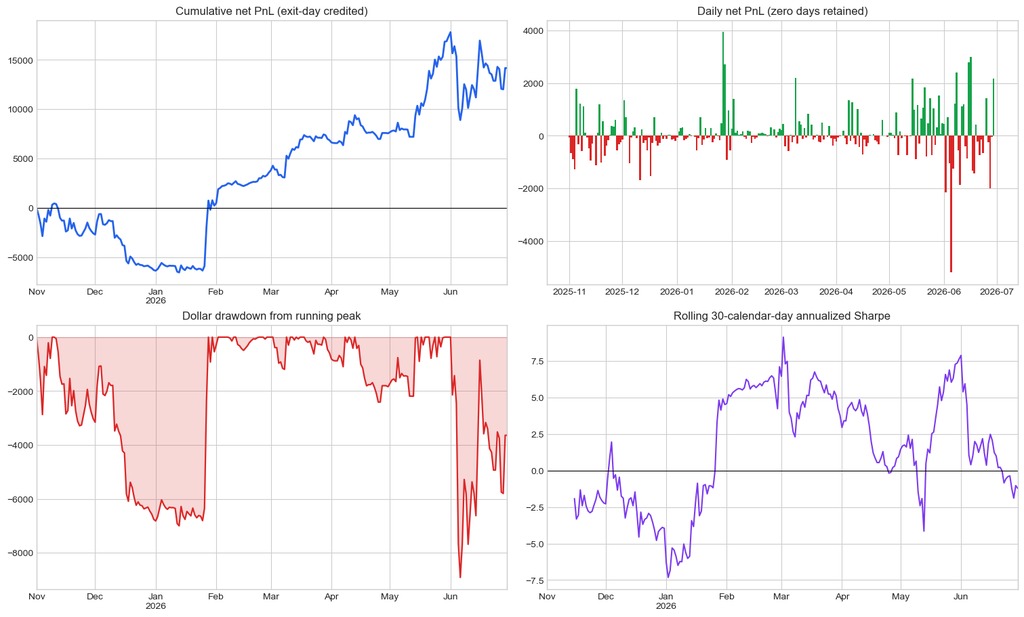

```python
fig, axes = plt.subplots(2, 2, figsize=(15, 9), constrained_layout=True)
daily['equity'].plot(ax=axes[0, 0], color='#2563eb', lw=2, title='Cumulative net PnL (exit-day credited)')
axes[0, 0].axhline(0, color='black', lw=.8)
daily['drawdown'].plot(ax=axes[1, 0], color='#dc2626', lw=1.6, title='Dollar drawdown from running peak')
axes[1, 0].fill_between(daily.index, daily['drawdown'], 0, color='#dc2626', alpha=.18)
colors = np.where(daily['net_usd'] >= 0, '#16a34a', '#dc2626')
axes[0, 1].bar(daily.index, daily['net_usd'], color=colors, width=1.0)
axes[0, 1].set_title('Daily net PnL (zero days retained)')
daily['rolling_30d_sharpe'].plot(ax=axes[1, 1], color='#7c3aed', title='Rolling 30-calendar-day annualized Sharpe')
axes[1, 1].axhline(0, color='black', lw=.8)
for ax in axes.flat:
    ax.set_xlabel('')
plt.show()
```

## 3. Entry-fold and coin breadth

A positive overall mean can be produced by a small number of regimes or coins. These tables make the breadth visible rather than relying on one aggregate Sharpe.

```python
by_entry_fold = trades.groupby('fold').agg(
    trades=('net_bp', 'size'),
    mean_bp=('net_bp', 'mean'),
    median_bp=('net_bp', 'median'),
    hit_rate=('net_bp', lambda x: (x > 0).mean()),
    net_usd=('net_usd', 'sum'),
).sort_index()
by_entry_fold['positive'] = by_entry_fold['net_usd'] > 0

by_coin = trades.groupby('coin').agg(
    trades=('net_bp', 'size'),
    mean_bp=('net_bp', 'mean'),
    median_bp=('net_bp', 'median'),
    hit_rate=('net_bp', lambda x: (x > 0).mean()),
    net_usd=('net_usd', 'sum'),
).sort_values('net_usd', ascending=False)

display(by_entry_fold)
display(by_coin)
```

| fold | trades | mean_bp | median_bp | hit_rate | net_usd | positive |
| --- | --- | --- | --- | --- | --- | --- |
| 202511 | 256 | -20.206 | -27.409 | 0.453 | -2,586.371 | False |
| 202512 | 175 | -42.609 | -28.345 | 0.434 | -3,728.284 | False |
| 202601 | 215 | 69.658 | -4.225 | 0.488 | 7,488.231 | True |
| 202602 | 76 | 65.576 | 66.579 | 0.697 | 2,491.905 | True |
| 202603 | 156 | 40.880 | -7.431 | 0.494 | 3,188.637 | True |
| 202604 | 174 | 7.970 | 9.213 | 0.517 | 693.413 | True |
| 202605 | 361 | 58.582 | 19.219 | 0.554 | 10,574.015 | True |
| 202606 | 332 | -23.818 | -51.547 | 0.461 | -3,953.833 | False |

| coin | trades | mean_bp | median_bp | hit_rate | net_usd |
| --- | --- | --- | --- | --- | --- |
| HYPE | 1239 | 27.821 | 6.192 | 0.507 | 17,235.165 |
| BTC | 265 | 17.313 | 3.285 | 0.521 | 2,294.036 |
| SOL | 113 | -44.037 | -29.875 | 0.407 | -2,488.084 |
| ETH | 128 | -44.897 | -21.163 | 0.453 | -2,873.403 |

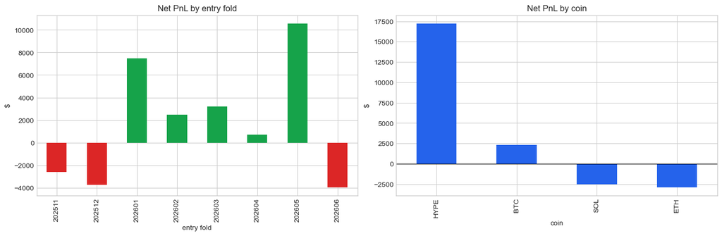

```python
fig, axes = plt.subplots(1, 2, figsize=(14, 4.5), constrained_layout=True)
by_entry_fold['net_usd'].plot.bar(ax=axes[0], color=np.where(by_entry_fold['net_usd'] >= 0, '#16a34a', '#dc2626'))
axes[0].set_title('Net PnL by entry fold')
axes[0].set_xlabel('entry fold')
axes[0].set_ylabel('$')
by_coin['net_usd'].plot.bar(ax=axes[1], color='#2563eb')
axes[1].axhline(0, color='black', lw=.8)
axes[1].set_title('Net PnL by coin')
axes[1].set_xlabel('coin')
axes[1].set_ylabel('$')
plt.show()
```

## 4. Return distribution and tail diagnostics

The strategy's trade returns are fat-tailed. The histogram is clipped only for visualization; every summary statistic and the backtest itself uses the unmodified observations.

|  | value |
| --- | --- |
| min bp | -1,089.922 |
| p01 bp | -746.040 |
| p05 bp | -485.809 |
| median bp | -0.275 |
| p95 bp | 555.355 |
| p99 bp | 939.860 |
| max bp | 1,557.897 |
| skew | 0.497 |
| excess kurtosis | 2.296 |
| mean after p01/p99 winsorization | 15.236 |

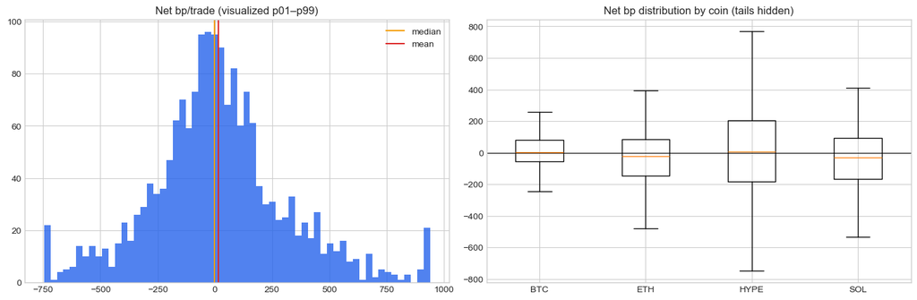

```python
q01, q99 = trades['net_bp'].quantile([.01, .99])
tail = pd.Series({
    'min bp': trades['net_bp'].min(),
    'p01 bp': q01,
    'p05 bp': trades['net_bp'].quantile(.05),
    'median bp': trades['net_bp'].median(),
    'p95 bp': trades['net_bp'].quantile(.95),
    'p99 bp': q99,
    'max bp': trades['net_bp'].max(),
    'skew': trades['net_bp'].skew(),
    'excess kurtosis': trades['net_bp'].kurt(),
    'mean after p01/p99 winsorization': trades['net_bp'].clip(q01, q99).mean(),
})
display(tail.to_frame('value'))

fig, axes = plt.subplots(1, 2, figsize=(14, 4.5), constrained_layout=True)
axes[0].hist(trades['net_bp'].clip(q01, q99), bins=60, color='#2563eb', alpha=.8)
axes[0].axvline(trades['net_bp'].median(), color='#f59e0b', label='median')
axes[0].axvline(trades['net_bp'].mean(), color='#dc2626', label='mean')
axes[0].set_title('Net bp/trade (visualized p01–p99)')
axes[0].legend()
coin_arrays = [trades.loc[trades['coin'] == coin, 'net_bp'].clip(q01, q99) for coin in sorted(trades['coin'].unique())]
axes[1].boxplot(coin_arrays, tick_labels=sorted(trades['coin'].unique()), showfliers=False)
axes[1].axhline(0, color='black', lw=.8)
axes[1].set_title('Net bp distribution by coin (tails hidden)')
plt.show()
```

## 5. Wallet, direction, and roster concentration

Contribution concentration is shown in dollars. It describes dependence on particular wallets; it is not a causal attribution of skill.

```python
wallets = trades.groupby('wallet').agg(
    trades=('net_bp', 'size'),
    mean_bp=('net_bp', 'mean'),
    hit_rate=('net_bp', lambda x: (x > 0).mean()),
    net_usd=('net_usd', 'sum'),
).sort_values('net_usd', ascending=False)
abs_total = wallets['net_usd'].abs().sum()
top5_abs_share = wallets['net_usd'].abs().nlargest(5).sum() / abs_total
hhi_abs = ((wallets['net_usd'].abs() / abs_total) ** 2).sum()

by_direction = trades.groupby('direction').agg(
    trades=('net_bp', 'size'), mean_bp=('net_bp', 'mean'),
    median_bp=('net_bp', 'median'), hit_rate=('net_bp', lambda x: (x > 0).mean()),
    net_usd=('net_usd', 'sum'))

overlap_rows = []
for previous, current in zip(wc.FOLDS[:-1], wc.FOLDS[1:]):
    a, b = set(rosters[str(previous)]), set(rosters[str(current)])
    overlap_rows.append({'from': previous, 'to': current, 'overlap': len(a & b), 'turnover': 30 - len(a & b)})
roster_turnover = pd.DataFrame(overlap_rows)

display(pd.Series({'unique contributing wallets': len(wallets), 'top-5 absolute contribution share': top5_abs_share, 'absolute-contribution HHI': hhi_abs}).to_frame('value'))
display(wallets.head(15))
display(by_direction)
display(roster_turnover)
```

|  | value |
| --- | --- |
| unique contributing wallets | 52.000 |
| top-5 absolute contribution share | 0.456 |
| absolute-contribution HHI | 0.058 |

| wallet | trades | mean_bp | hit_rate | net_usd |
| --- | --- | --- | --- | --- |
| 0x3cb800a5a8a4386bc87a09c85ec4b9c76ee95550 | 145 | 49.238 | 0.566 | 3,569.743 |
| 0xae6b807ec47e0b7900d1fe2a53885b4602748b03 | 102 | 58.528 | 0.549 | 2,984.944 |
| 0xafe62f929c84b4a7730ae98a3835a936fd86bde0 | 128 | 45.492 | 0.523 | 2,911.510 |
| 0xdc899ed4a80e7bbe7c86307715507c828901f196 | 124 | 37.559 | 0.500 | 2,328.645 |
| 0x1d14c6221aa536eb86360b611089d881cc5cd4b3 | 70 | 54.552 | 0.486 | 1,909.329 |
| 0x4331ca6ff2e4a342244a4b8bec962a43cbeb0b57 | 48 | 68.205 | 0.750 | 1,636.928 |
| 0x7d4886f385bf4cf5c8d5459736a17e800682206b | 30 | 97.665 | 0.500 | 1,464.970 |
| 0xe6e65bce41e7b66997da4a043a7683b1c5fdf7b3 | 33 | 85.453 | 0.606 | 1,409.968 |
| 0x329c787b163a730bd7900df2beb3ff4fe4670375 | 22 | 85.651 | 0.545 | 942.165 |
| 0xc22db2c04e054786426671cec0b766c07304fb20 | 82 | 21.574 | 0.500 | 884.551 |
| 0x6049ddfd35e4d9098a6367e36023f2a36792b642 | 2 | 452.627 | 1.000 | 452.627 |
| 0xad68fabb1bec8b08c8080ad165ae5bdec64136d6 | 30 | 28.363 | 0.500 | 425.438 |
| 0x0c657a1ed8c4c7c2083741059fc3cd27dc316ab9 | 45 | 17.746 | 0.533 | 399.280 |
| 0x81f6b887657b679d9e23153ffcd703e111010240 | 35 | 21.184 | 0.543 | 370.714 |
| 0x1003d8c532e5178673668e5f3aa48dc399ee940c | 7 | 90.093 | 0.571 | 315.327 |

| direction | trades | mean_bp | median_bp | hit_rate | net_usd |
| --- | --- | --- | --- | --- | --- |
| long | 1525 | 18.151 | -0.275 | 0.498 | 13,840.278 |
| short | 220 | 2.977 | 0.054 | 0.500 | 327.436 |

|  | from | to | overlap | turnover |
| --- | --- | --- | --- | --- |
| 0 | 202511 | 202512 | 15 | 15 |
| 1 | 202512 | 202601 | 15 | 15 |
| 2 | 202601 | 202602 | 9 | 21 |
| 3 | 202602 | 202603 | 13 | 17 |
| 4 | 202603 | 202604 | 14 | 16 |
| 5 | 202604 | 202605 | 15 | 15 |
| 6 | 202605 | 202606 | 16 | 14 |

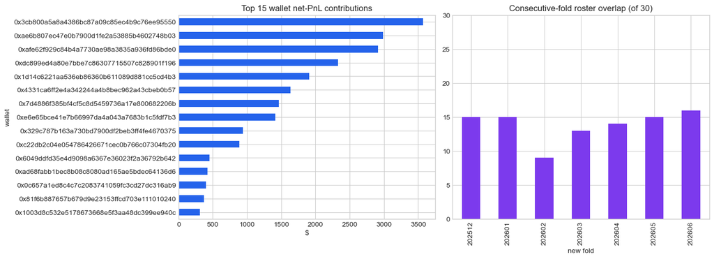

```python
fig, axes = plt.subplots(1, 2, figsize=(14, 5), constrained_layout=True)
wallets.head(15).sort_values('net_usd')['net_usd'].plot.barh(ax=axes[0], color='#2563eb')
axes[0].set_title('Top 15 wallet net-PnL contributions')
axes[0].set_xlabel('$')
roster_turnover.set_index('to')['overlap'].plot.bar(ax=axes[1], color='#7c3aed')
axes[1].set_ylim(0, 30)
axes[1].set_title('Consecutive-fold roster overlap (of 30)')
axes[1].set_xlabel('new fold')
plt.show()
```

## 6. Capacity funnel and caveats

```python
funnel = pd.DataFrame(funnels).T.astype(int)
funnel.loc['TOTAL'] = funnel.sum()
display(funnel)

print(f"Reproduced audited book: {len(trades):,} supported trades, ${trades['net_usd'].sum():,.2f} net, {trades['net_bp'].mean():.3f} bp/trade.")
print(f'Registered missing-outcome stress: {adverse_mean_bp:.3f} to {favorable_mean_bp:.3f} bp/trade; ${adverse_pnl:,.2f} to ${favorable_pnl:,.2f}.')
print('Interpretation: positive descriptive mean, but burned and missingness-unresolved; direction not established or deployable.')
```

|  | n_candidates | n_accepted_capacity | n_skip_wallet_coin | n_skip_coin_cap |
| --- | --- | --- | --- | --- |
| 202511 | 719 | 256 | 463 | 0 |
| 202512 | 404 | 175 | 229 | 0 |
| 202601 | 618 | 215 | 403 | 0 |
| 202602 | 378 | 76 | 302 | 0 |
| 202603 | 467 | 156 | 311 | 0 |
| 202604 | 488 | 174 | 314 | 0 |
| 202605 | 3269 | 376 | 2893 | 0 |
| 202606 | 1576 | 332 | 1244 | 0 |
| TOTAL | 7919 | 1760 | 6159 | 0 |

```
Reproduced audited book: 1,745 supported trades, $14,167.71 net, 16.238 bp/trade.
Registered missing-outcome stress: -0.946 to 33.145 bp/trade; $-832.29 to $29,167.71.
Interpretation: positive descriptive mean, but burned and missingness-unresolved; direction not established or deployable.
```

## 7. Same-coin long/short policy diagnostic

The baseline keeps separate virtual sleeves when copied wallets are long and short the same coin. This burned diagnostic compares it with a deterministic suppression rule: while any sleeve is open in a coin, new opposite-direction sleeves are skipped. Both arms replay the full pre-capacity candidate stream independently; this is not netting at an exchange price, early closing, or a flip rule.

```python
from research.studies.copy_cohort import same_coin_direction_policy as sc

policy_report = json.loads(sc.OUT.read_text())
assert policy_report['status'] == 'BURNED_SAME_COIN_EXECUTION_DIAGNOSTIC'
assert policy_report['decision']['claim'] == 'UNRESOLVED'
policy_arms = ['VIRTUAL_SLEEVES', 'ONE_SIDE_PER_COIN']
policy_summary = pd.DataFrame({arm: {
    'accepted': policy_report['books'][arm]['accepted'],
    'supported': policy_report['books'][arm]['supported_trades'],
    'net USD': policy_report['books'][arm]['net_usd'],
    'mean bp/trade': policy_report['books'][arm]['net_mean_bp_per_trade'],
    'median bp/trade': policy_report['books'][arm]['net_median_bp_per_trade'],
    'Sharpe': policy_report['books'][arm]['annualized_sharpe'],
    'Sortino': policy_report['books'][arm]['annualized_sortino'],
    'positive months': policy_report['books'][arm]['positive_exit_months'],
    'average gross USD': policy_report['books'][arm]['exposure']['average_gross_usd'],
    'average abs-net USD': policy_report['books'][arm]['exposure']['average_absolute_net_usd'],
    'mixed active-coin share': policy_report['books'][arm]['exposure']['mixed_active_coin_share'],
} for arm in policy_arms}).T
display(policy_summary.style.format(precision=3))

policy_funnel = pd.DataFrame(policy_report['funnels']['ONE_SIDE_PER_COIN']).T
policy_funnel.loc['TOTAL'] = policy_funnel.sum()
display(policy_funnel)
```

|  | accepted | supported | net USD | mean bp/trade | median bp/trade | Sharpe | Sortino | positive months | average gross USD | average abs-net USD | mixed active-coin share |
| --- | --- | --- | --- | --- | --- | --- | --- | --- | --- | --- | --- |
| VIRTUAL_SLEEVES | 1760.000 | 1745.000 | 14167.714 | 16.238 | -0.275 | 1.321 | 2.077 | 5.000 | 12121.212 | 11058.573 | 0.083 |
| ONE_SIDE_PER_COIN | 1675.000 | 1661.000 | 16464.065 | 19.824 | 1.696 | 1.517 | 2.414 | 5.000 | 11535.813 | 11535.813 | 0.000 |

|  | n_accepted_capacity | n_candidates | n_skip_coin_cap | n_skip_opposite_direction | n_skip_wallet_coin |
| --- | --- | --- | --- | --- | --- |
| 202511 | 232 | 719 | 0 | 59 | 428 |
| 202512 | 159 | 404 | 0 | 26 | 219 |
| 202601 | 203 | 618 | 0 | 17 | 398 |
| 202602 | 76 | 378 | 0 | 0 | 302 |
| 202603 | 155 | 467 | 0 | 1 | 311 |
| 202604 | 172 | 488 | 0 | 2 | 314 |
| 202605 | 347 | 3269 | 0 | 66 | 2856 |
| 202606 | 331 | 1576 | 0 | 1 | 1244 |
| TOTAL | 1675 | 7919 | 0 | 172 | 6072 |

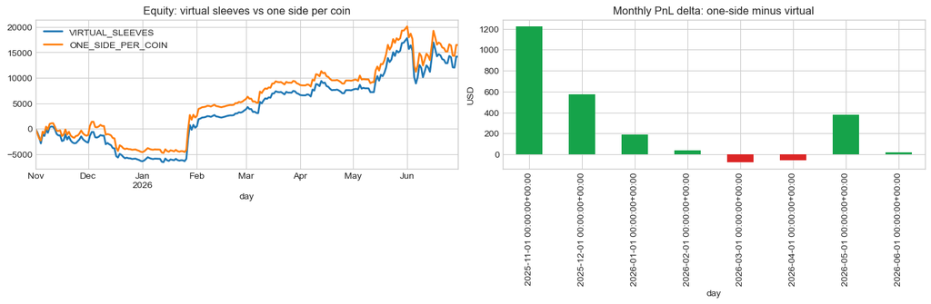

```
Descriptive delta: $2,296.35; 95% block-bootstrap CI $-166.24 to $4,966.90; p=0.081.
Conservative missingness CI: $-2,585.43 to $6,313.82.
Observed MDE80: +$3,929.45 / -$3,461.00; power at ±$2,500: 39.9% / 56.4%.
Missingness gates pass: False (May exceeds the 2% per-fold ceiling). Final claim: UNRESOLVED.
Interpretation: underpowered positive execution residual on burned data; not established, not a null, and not deployable.
```

```python
policy_daily = pd.DataFrame({
    arm: policy_report['books'][arm]['daily_pnl_usd'] for arm in policy_arms
}, index=calendar)
fig, axes = plt.subplots(1, 2, figsize=(14, 4.5), constrained_layout=True)
policy_daily.cumsum().plot(ax=axes[0], lw=2, title='Equity: virtual sleeves vs one side per coin')
policy_month_delta = (policy_daily['ONE_SIDE_PER_COIN'] - policy_daily['VIRTUAL_SLEEVES']).resample('MS').sum()
policy_month_delta.plot.bar(ax=axes[1], color=np.where(policy_month_delta >= 0, '#16a34a', '#dc2626'))
axes[1].set_title('Monthly PnL delta: one-side minus virtual')
axes[1].set_ylabel('USD')
plt.show()

obs = policy_report['inference']['observed']
decision = policy_report['decision']
miss = policy_report['missingness']['gates']
print(f"Descriptive delta: ${obs['point_usd']:,.2f}; 95% block-bootstrap CI ${obs['ci95_usd'][0]:,.2f} to ${obs['ci95_usd'][1]:,.2f}; p={obs['p_two_sided']:.3f}.")
print(f"Conservative missingness CI: ${decision['conservative_missingness_ci95_usd'][0]:,.2f} to ${decision['conservative_missingness_ci95_usd'][1]:,.2f}.")
print(f"Observed MDE80: +${obs['mde80_positive_usd']:,.2f} / -${obs['mde80_negative_usd']:,.2f}; power at ±$2,500: {obs['power_at_positive_2500']:.1%} / {obs['power_at_negative_2500']:.1%}.")
print(f"Missingness gates pass: {miss['pass']} (May exceeds the 2% per-fold ceiling). Final claim: {decision['claim']}.")
print('Interpretation: underpowered positive execution residual on burned data; not established, not a null, and not deployable.')
```

## 8. Relative-notional CR≤50 entry filter

This burned diagnostic rejects a candidate when its notional is more than 50 times that wallet's exact median majors opening notional over the same strict-prior three formation months. The filter runs before capacity; unknown formation scales pass through. Consensus, BOT500, and the same-coin policy are excluded.

```python
from research.studies.copy_cohort import notional_cr50_filter as cr50

cr50_report = json.loads(cr50.OUT.read_text())
assert cr50_report['status'] == 'BURNED_CR50_ENTRY_FILTER_DIAGNOSTIC'
cr50_arms = ['VIRTUAL_SLEEVES', 'CR50']
cr50_summary = pd.DataFrame({arm: {
    'accepted': cr50_report['books'][arm]['accepted'],
    'supported': cr50_report['books'][arm]['supported_trades'],
    'net USD': cr50_report['books'][arm]['net_usd'],
    'mean bp/trade': cr50_report['books'][arm]['net_mean_bp_per_trade'],
    'median bp/trade': cr50_report['books'][arm]['net_median_bp_per_trade'],
    'Sharpe': cr50_report['books'][arm]['annualized_sharpe'],
    'Sortino': cr50_report['books'][arm]['annualized_sortino'],
    'positive months': cr50_report['books'][arm]['positive_exit_months'],
} for arm in cr50_arms}).T
display(cr50_summary.style.format(precision=3))

f = cr50_report['construction']['filter']
display(pd.Series({
    'candidate entries': f['n_candidates'],
    'entries with prior scale': f['n_with_scale'],
    'unknown-scale pass-through': f['n_scale_passthrough'],
    'CR>50 rejected candidates': f['n_rejected'],
    'maximum kept CR': f['max_kept_cr'],
    'minimum rejected CR': f['min_rejected_cr'],
}).to_frame('value'))
```

|  | accepted | supported | net USD | mean bp/trade | median bp/trade | Sharpe | Sortino | positive months |
| --- | --- | --- | --- | --- | --- | --- | --- | --- |
| VIRTUAL_SLEEVES | 1760.000 | 1745.000 | 14167.714 | 16.238 | -0.275 | 1.321 | 2.077 | 5.000 |
| CR50 | 1760.000 | 1745.000 | 14167.714 | 16.238 | -0.275 | 1.321 | 2.077 | 5.000 |

|  | value |
| --- | --- |
| candidate entries | 7,919.000 |
| entries with prior scale | 7,774.000 |
| unknown-scale pass-through | 145.000 |
| CR>50 rejected candidates | 1.000 |
| maximum kept CR | 24.307 |
| minimum rejected CR | 96.808 |

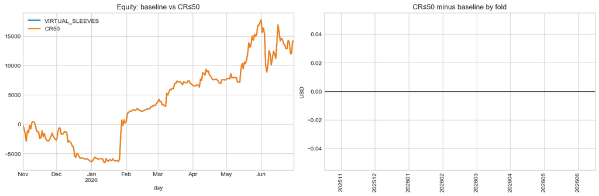

```
Book delta: $0.00; paired 95% CI $0.00 to $0.00.
The only CR>50 candidate was already ineligible because the same wallet had an open HYPE sleeve; accepted and supported identities are unchanged.
Registered claim: UNRESOLVED because May breaches the absolute per-fold missingness gate.
Interpretation: structurally unactivated selector / exact fixed-book identity; this does not estimate benefit when CR≤50 actually binds.
```

```python
cr50_daily = pd.DataFrame({
    arm: cr50_report['books'][arm]['daily_pnl_usd'] for arm in cr50_arms
}, index=calendar)
fig, axes = plt.subplots(1, 2, figsize=(14, 4.5), constrained_layout=True)
cr50_daily.cumsum().plot(ax=axes[0], lw=2, title='Equity: baseline vs CR≤50')
fold_delta = pd.Series(cr50_report['cross_unit_combination']['entry_fold']['deltas_usd'], dtype=float)
fold_delta.plot.bar(ax=axes[1], color='#64748b')
axes[1].axhline(0, color='black', lw=.8)
axes[1].set_title('CR≤50 minus baseline by fold')
axes[1].set_ylabel('USD')
plt.show()

obs50 = cr50_report['inference']['observed']
print(f"Book delta: ${obs50['point_usd']:,.2f}; paired 95% CI ${obs50['ci95_usd'][0]:,.2f} to ${obs50['ci95_usd'][1]:,.2f}.")
print('The only CR>50 candidate was already ineligible because the same wallet had an open HYPE sleeve; accepted and supported identities are unchanged.')
print(f"Registered claim: {cr50_report['decision']['claim']} because May breaches the absolute per-fold missingness gate.")
print('Interpretation: structurally unactivated selector / exact fixed-book identity; this does not estimate benefit when CR≤50 actually binds.')
```

### Reading the notebook correctly

- The equity curve is a fixed-$5k, closed-trade accounting curve—not returns on a continuously reinvested fund.
- Sharpe and Sortino include zero-PnL calendar days and use exit-day attribution. They are descriptive and sensitive to the selected horizon.
- Fifteen capacity-accepted entries have unavailable outcomes and are omitted from the headline PnL statistics. May breaches the registered per-fold missingness limit, and the registered ±2,000 bp stress can flip the absolute sign.
- The strategy has a positive mean but a slightly negative median and limited coin breadth. Tail, HYPE, and wallet concentration diagnostics should be read alongside the headline Sharpe.
- The same-coin suppression policy descriptively adds $2,296 and raises Sharpe from 1.32 to 1.52, but its observed CI crosses zero, its MDE exceeds the $2,500 materiality target, and May fails the missingness gate. It remains an underpowered positive / unresolved residual.
- CR≤50 rejects one raw candidate, but that row was already blocked by the one-open-wallet×coin rule. The realized CR50 and baseline books are exactly identical; this is a structurally unactivated selector, not evidence about its effect when it binds.
- The folds and this strategy family have been repeatedly inspected. Nothing in this notebook is fresh OOS evidence or permission to deploy.